```python
import gymnasium as gym
import numpy as np
from tqdm import tqdm
from gymnasium.wrappers import RecordEpisodeStatistics, RecordVideo
import matplotlib.pyplot as plt
import copy
import matplotlib.pyplot as plt
import seaborn as sns
from mpl_toolkits.mplot3d import Axes3D
from IPython.display import YouTubeVideo, Video, Image
```

# The Under-powered Mountain Car

07 April 2025

```python
rng = np.random.default_rng()
```

### How things all start

```python
Video("Videos/agent-tiny-alpha-episode-0.mp4", embed=True)
```

[video not shown]

### The Goal

```python
vid = YouTubeVideo('Ot-0cz7ji6Y', width=800, height=500, start=87)
display(vid)
```

[video not shown]

### Progress in 2000 episodes

```python
Video("Videos/agent-episode-2000.mp4", embed=True)
```

[video not shown]

### 8000 episodes: Peak behavior

```python
Video("Videos/agent-episode-8000.mp4", embed=True)
```

[video not shown]

```python
ENV = gym.make("MountainCar-v0", render_mode="rgb_array", max_episode_steps=1000, goal_velocity=0.07)
ENV = RecordEpisodeStatistics(ENV)
```

## Problem

State: position $x$, velocity $\dot{x}$

Action: forward throttle $1$, still $0$, reverse throttle $-1$

*A continuous state space, with real numbers instead of just a grid!*

## Solution

Construct a feature space that maps to the continuous state space and use a weight vector $\mathbf{w}$ to weight the features

$q: S \times A \times \mathbb{R}^d \rightarrow \mathbb{R}$

The action is included because I use SARSA (State Action Reward State **Action**) and thus must measure value by action, not just by state

```python
obs_space = ENV.observation_space
```

```python
x_pos_bounds = obs_space.low[0], obs_space.high[0]
x_vel_bounds = obs_space.low[1], obs_space.high[1]
```

## Tile Coding: Defining the tiles in our feature vector $\mathbf{x}$

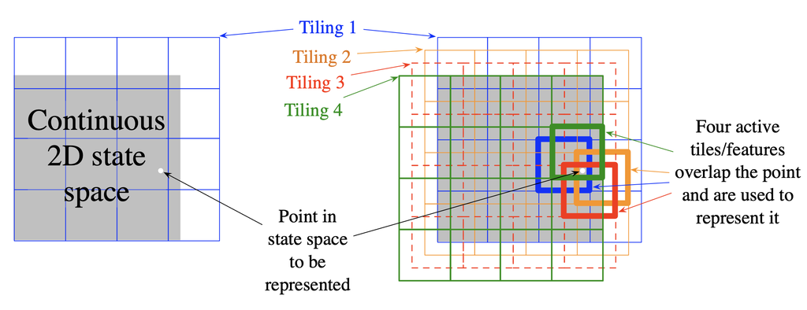

```python
Image(filename='tilings.png')
```

We have a **k = 2** dim space.

Recommended number of tilings is then 2^n >= 4k, which is n >= root(8). So any number of tilings n >= 3 is recommended. Example 10.1 uses **n=8**, which we will do.

That means each tiling is an 8x8 grid. 8 of them means there are **d = 8 x 8 x 8 = 512** tiles, or features.

These are not square tiles, because the continuous spaces are bounded differently. We will say $s_0 = x$ and $s_1 = \dot{x}$. With that

$$-1.2 <= s_0 <= 0.6$$ $$-0.07 <= s_1 <= 0.07$$

Each tile covers 1/8th the bounded distance, so the widths are: $$w_0 = \frac{0.6-(-1.2)}{8} = 0.225$$ $$w_1 = \frac{0.07-(-0.07)}{8} = 0.0175$$

## How to Offset Tiling

The fundamental units of the feature space (dimensions of non-overlapping tile space) are: $$\frac{w_0}{n} = \frac{0.225}{8} = 0.028125$$ $$\frac{w_1}{n} = \frac{0.0175}{8} = 0.0021875$$

Every state now lights up the tiles in the $(\frac{w_0}{n},\frac{w_1}{n})$ unit uniquely, such that moving the state in any single cartesion direction creates a different feature space, and thus a different action-value.

But how do you actually offset the tiles?

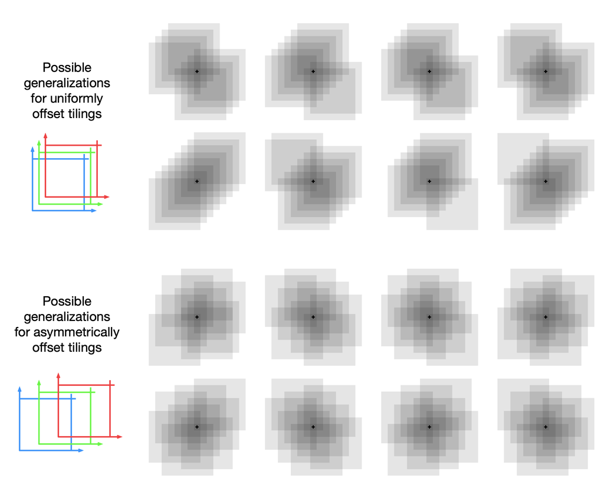

```python
Image(filename='./offsets.png')
```

Finally, we can calculate the displacement vector for each tiling. Because k=2, we take the first 2 odd integers, $(1,3)$ as our "unit" displacement. Then we calculate our final displacement vector with the unit $(\frac{w_0}{n},\frac{w_1}{n})$: $$(1,3) \times (\frac{w_0}{n},\frac{w_1}{n})$$ $$(1,3) \times (0.028125,0.0021875)$$ $$(0.028125,0.0065625)$$

That is our displacement vector with which to calculate all tilings.

```python
x_pos_tile_width = (x_pos_bounds[1] - x_pos_bounds[0])/8
print(f"x_pos_tile_width \n {x_pos_tile_width}")
x_vel_tile_width = (x_vel_bounds[1] - x_vel_bounds[0])/8
print(f"x_vel_tile_width \n {x_vel_tile_width}")
```

```
x_pos_tile_width
 0.22500000894069672
x_vel_tile_width
 0.017500000074505806
```

First we start with the base tiling. "Base" because it starts at what we start this tiling at the start of the bounds.

```python
x_pos_tiling = np.arange(x_pos_bounds[0], x_pos_bounds[1], x_pos_tile_width)
x_vel_tiling = np.arange(x_vel_bounds[0], x_vel_bounds[1], x_vel_tile_width)
print(f"x_pos_tiling \n {x_pos_tiling}")
print(f"y_vel_tiling \n {x_vel_tiling}")
```

```
x_pos_tiling
 [-1.20000005 -0.97500002 -0.75       -0.52499998 -0.29999995 -0.07499993
  0.1500001   0.37500012]
y_vel_tiling
 [-7.00000003e-02 -5.25000021e-02 -3.50000039e-02 -1.75000057e-02
 -7.45058060e-09  1.74999908e-02  3.49999890e-02  5.24999872e-02]
```

Our first 2d tiling:

```python
tiling = np.stack((x_pos_tiling,x_vel_tiling), axis=1)
tiling
```

```
array([[-1.20000005e+00, -7.00000003e-02],
       [-9.75000024e-01, -5.25000021e-02],
       [-7.50000000e-01, -3.50000039e-02],
       [-5.24999976e-01, -1.75000057e-02],
       [-2.99999952e-01, -7.45058060e-09],
       [-7.49999285e-02,  1.74999908e-02],
       [ 1.50000095e-01,  3.49999890e-02],
       [ 3.75000119e-01,  5.24999872e-02]])
```

Now we calculate our displacement:

```python
k = 2
n = 8
unit_displacement = np.array([1,3])
displacement = unit_displacement * np.array([x_pos_tile_width/n, x_vel_tile_width/n])
displacement
```

```
array([0.028125 , 0.0065625])
```

Then create all tilings. While technically there are 8 tilings of 64 squares (8x8) we really are just storing the start intervals of all tilings. Again, actually being "on or off" is handled in a bit.

```python
multipliers = np.arange(0,n)
tilings = tiling + multipliers[:, None, None] * displacement
print(tilings.shape)
```

```
(8, 8, 2)
```

Tiling interval starts for all 8 tilings are now:

```python
[tiling[0] for tiling in tilings]
```

```
[array([-1.20000005, -0.07      ]),
 array([-1.17187505, -0.0634375 ]),
 array([-1.14375005, -0.056875  ]),
 array([-1.11562504, -0.0503125 ]),
 array([-1.08750004, -0.04375   ]),
 array([-1.05937504, -0.0371875 ]),
 array([-1.03125004, -0.030625  ]),
 array([-1.00312504, -0.0240625 ])]
```

Tiling interval ends:

```python
tilings
```

```
array([[[-1.20000005e+00, -7.00000003e-02],
        [-9.75000024e-01, -5.25000021e-02],
        [-7.50000000e-01, -3.50000039e-02],
        [-5.24999976e-01, -1.75000057e-02],
        [-2.99999952e-01, -7.45058060e-09],
        [-7.49999285e-02,  1.74999908e-02],
        [ 1.50000095e-01,  3.49999890e-02],
        [ 3.75000119e-01,  5.24999872e-02]],

       [[-1.17187505e+00, -6.34375003e-02],
        [-9.46875023e-01, -4.59375021e-02],
        [-7.21874999e-01, -2.84375038e-02],
        [-4.96874975e-01, -1.09375056e-02],
        [-2.71874951e-01,  6.56249258e-03],
        [-4.68749274e-02,  2.40624908e-02],
        [ 1.78125096e-01,  4.15624890e-02],
        [ 4.03125120e-01,  5.90624872e-02]],

       [[-1.14375005e+00, -5.68750002e-02],
        [-9.18750022e-01, -3.93750020e-02],
        [-6.93749998e-01, -2.18750038e-02],
        [-4.68749974e-01, -4.37500561e-03],
        [-2.43749950e-01,  1.31249926e-02],
        [-1.87499262e-02,  3.06249908e-02],
        [ 2.06250098e-01,  4.81249890e-02],
        [ 4.31250121e-01,  6.56249872e-02]],

       [[-1.11562504e+00, -5.03125002e-02],
        [-8.90625020e-01, -3.28125020e-02],
        [-6.65624997e-01, -1.53125038e-02],
        [-4.40624973e-01,  2.18749442e-03],
        [-2.15624949e-01,  1.96874926e-02],
        [ 9.37507488e-03,  3.71874908e-02],
        [ 2.34375099e-01,  5.46874891e-02],
        [ 4.59375123e-01,  7.21874873e-02]],

       [[-1.08750004e+00, -4.37500002e-02],
        [-8.62500019e-01, -2.62500020e-02],
        [-6.37499996e-01, -8.75000376e-03],
        [-4.12499972e-01,  8.74999445e-03],
```

[output cut: 16 more lines]

```
        [-5.81249993e-01,  4.37499629e-03],
        [-3.56249969e-01,  2.18749945e-02],
        [-1.31249946e-01,  3.93749927e-02],
        [ 9.37500782e-02,  5.68749909e-02],
        [ 3.18750102e-01,  7.43749891e-02],
        [ 5.43750126e-01,  9.18749874e-02]],

       [[-1.00312504e+00, -2.40625001e-02],
        [-7.78125016e-01, -6.56250189e-03],
        [-5.53124992e-01,  1.09374963e-02],
        [-3.28124968e-01,  2.84374945e-02],
        [-1.03124944e-01,  4.59374927e-02],
        [ 1.21875079e-01,  6.34374910e-02],
        [ 3.46875103e-01,  8.09374892e-02],
        [ 5.71875127e-01,  9.84374874e-02]]])
```

```python
[tiling[len(tiling)-1] for tiling in tilings]
```

```
[array([0.37500012, 0.05249999]),
 array([0.40312512, 0.05906249]),
 array([0.43125012, 0.06562499]),
 array([0.45937512, 0.07218749]),
 array([0.48750012, 0.07874999]),
 array([0.51562512, 0.08531249]),
 array([0.54375013, 0.09187499]),
 array([0.57187513, 0.09843749])]
```

Now we design a function to ask what the feature vector looks like given a certain state vector (a.k.a. which featurs are "on" or "off" given the total state)

```python
def get_features(s,a):
    """
    Let it be known that this is an attempt at a possibly vectorized 2d tiling impl
    that is BUGGY. It requires much larger alpha to not get stuck in training somewhere
    due to an issue with tiling holes.
    """

    s0, s1 = s
    print(tilings.shape)
    s0_features = (s0 >= tilings[:,:,0]) & ((s0 - x_pos_tile_width) <= tilings[:,:,0])
    s0_features[np.where(np.all(s0_features == False, axis=1)),0] = True # ceiling application for too far offset tiles
    s0_features = np.where(s0_features)
    s1_features = (s1 >= tilings[:,:,1]) & ((s1 - x_vel_tile_width) <= tilings[:,:,1])
    s1_features[np.where(np.all(s1_features == False, axis=1)),0] = True # ceiling application for too far offset tiles
    s1_features = np.where(s1_features)

    print(s0_features)
    print(s1_features)

    # a * 512 + tile * 64 + s1 * 8 + s2
    i = a * n*n*n + s1_features[0] * (n*n) + s1_features[1] * n + s0_features[1]
    print(i)

    x = np.zeros((n*n*n*3), dtype=int)
    x[i] = 1

    return x
```

Sample observation and response

```python
s = np.array([0.6, 0.07])
print(f"State \n {s}")
get_features(s,0).shape
```

```
State
 [0.6  0.07]
(8, 8, 2)
(array([0, 1, 2, 3, 4, 5, 6, 7]), array([7, 7, 7, 7, 7, 7, 7, 7]))
(array([0, 1, 2, 3, 4, 5, 6, 7]), array([0, 7, 7, 6, 6, 6, 5, 5]))
[  7 127 191 247 311 375 431 495]
```

```
(1536,)
```

## Actual Action-Value Equation

Now we create a linear action-value function of the car's state: $$q = \textbf{w}^\top\textbf{x}(s,a) = \sum_{i=1}^{d} w_i x_i(s)$$ We already have the vector $\textbf{x}$ defined, so we just need a vector $\textbf{w}$ that represents the weights associated to each feature. This is trivial, as it is 1D vector of the same size as $\textbf{x}$.

Now we build our agent that learns how to reach the goal. We will use **semi-gradient SARSA** (semi-gradient because the gradient is built off a bootstrapped, or esptimated, understanding of the full return).

```python
class Agent:

    def __init__(self, env):
        self.env = env
        self.epsilon = 0.1
        self.n = 8  # number of tiles per dimension

        self.alpha = 1/(2*n)
        self.gamma = 1.0

        self.data = []

        self.w = np.zeros(3*n*n*n)
        obs_space = env.observation_space

        self.x_pos_bounds = obs_space.low[0], obs_space.high[0]
        self.x_vel_bounds = obs_space.low[1], obs_space.high[1]

        self.x_pos_tile_width = (self.x_pos_bounds[1] - self.x_pos_bounds[0]) / self.n
        self.x_vel_tile_width = (self.x_vel_bounds[1] - self.x_vel_bounds[0]) / self.n

        displacement = np.array([1, 3])
        self.tilings = []

        for i in range(self.n):
            offset = i * (displacement * np.array([self.x_pos_tile_width, self.x_vel_tile_width]) / self.n)
            x_offsets = np.linspace(self.x_pos_bounds[0] + offset[0],
                                    self.x_pos_bounds[1] + offset[0] - self.x_pos_tile_width,
                                    self.n)
            v_offsets = np.linspace(self.x_vel_bounds[0] + offset[1],
                                    self.x_vel_bounds[1] + offset[1] - self.x_vel_tile_width,
                                    self.n)
            grid = np.array(np.meshgrid(x_offsets, v_offsets)).T  # shape (n, n, 2)
            self.tilings.append(grid)

        self.tilings = np.array(self.tilings)  # shape (num_tilings, n, n, 2)



    def _policy(self, s):

        if rng.random() < self.epsilon:
            return self.env.action_space.sample()
        else:
            qs = np.array([self._q(s,a) for a in [0,1,2]])
            return np.argmax(qs)

    def _q(self, s, a):
        return np.sum(self.w[np.where(self._x(s, a))])

    def _x(self, s, a):
        """This solution works but is extremely slow

        Please use the tiling provided at
        http://incompleteideas.net/tiles/tiles3.html
        for an extremely fast hashing solution
        """

        x = np.zeros(self.n * self.n * self.n * 3, dtype=int)
        s0, s1 = s

        for f in range(self.n):
            tiling = self.tilings[f]  # shape (n, n, 2)
            for i in range(self.n):
                for j in range(self.n):
                    tile_pos = tiling[i, j]
                    if (tile_pos[0] <= s0 < tile_pos[0] + self.x_pos_tile_width and
                        tile_pos[1] <= s1 < tile_pos[1] + self.x_vel_tile_width):
                        idx = a * self.n * self.n * self.n + f * self.n * self.n + i * self.n + j
                        x[idx] = 1
                        break
                else:
                    continue
                break
        return x


    def data(self):
        return self.data

    def learn(self, episodes=10000):
        episode_tracker = [0,300, 1000, 5000, 9000]
        self.epsilon = 0.3

        for ep in tqdm(range(0,episodes)):
            S = self.env.reset()[0]
            A = self._policy(S)

            truncated = False
            terminated = False

            while not truncated and not terminated:

                S_p, R, terminated, truncated, info = self.env.step(A)

                if terminated:
                    self.w += self.alpha * (R - self._q(S, A)) * self._x(S,A)
                else:
                    A_p = self._policy(S_p)
                    self.w += self.alpha * (R + self.gamma * self._q(S_p, A_p) - self._q(S, A)) * self._x(S,A)
                    S = S_p
                    A = A_p

                if truncated or terminated:
                    if ep in episode_tracker:
                        info["episode"]["q"]  = self._cost_to_go()
                    self.data = np.append(self.data, info)

    def _cost_to_go(self):
        self.epsilon = 0

        x_vals = np.linspace(-1.2, 0.6, num=50)      # position
        xdot_vals = np.linspace(-0.07, 0.07, num=50) # velocity

        grid = np.array([[x, xdot] for x in x_vals for xdot in xdot_vals])

        z = np.array([
            max(self._q(state, a) for a in [0, 1, 2])
            for state in grid
        ])

        return z
```

```python
EPISODES=10000
trigger = lambda t: t % (EPISODES/5) == 0
#trigger = False
video_folder = "./Videos"
RecordedEnv = RecordVideo(ENV, video_folder=video_folder, name_prefix="agent", episode_trigger=trigger)
```

```python
agent = Agent(RecordedEnv)
```

```python
agent.learn(EPISODES)
```

```
100%|██████████████████████████████████████████████████████████████████████████████████████████████████████████████████████████████████████████████████████████████████████████████████████████████████████████| 10000/10000 [18:08<00:00,  9.19it/s]
```

```python
zs = np.array([d["episode"]["q"] for d in agent.data if "q" in  d["episode"]])

def plot_cost_to_go_contour(agent, x_range=(-1.2, 0.6), xdot_range=(-0.07, 0.07), resolution=50):
    x_vals = np.linspace(*x_range, resolution)
    xdot_vals = np.linspace(*xdot_range, resolution)

    X, Y = np.meshgrid(x_vals, xdot_vals)
    Z = np.zeros_like(X)

    fig = plt.figure(figsize=(18, 10))
    episode_tracker = [0,300, 1000, 5000, 9000]

    for idx in range(0,zs.shape[0]):
        Z = np.zeros_like(X)
        for i in range(resolution):
            for j in range(resolution):
                s = (X[i, j], Y[i, j])
                Z[i, j] = -1 * zs[idx][i * resolution + j]

        ax = fig.add_subplot(2, 3, idx + 1, projection='3d')
        surf = ax.plot_surface(X, Y, Z, cmap='viridis', edgecolor='none')
        ax.set_xlabel('Position')
        ax.set_ylabel('Velocity')
        ax.set_zlabel('Cost-to-Go')
        ax.set_title(f'Episode {episode_tracker[idx]}')


    plt.tight_layout()
    plt.show()
```

## Cost-to-go Over Training

```python
plot_cost_to_go_contour(agent)
```

[output not shown]

```python
def plot_rewards():
    rewards = [r["episode"]["r"] for r in agent.data]
    rewards = np.convolve(rewards, np.ones(10)/10, mode='valid')
    plt.plot(range(len(rewards)), rewards, label="Rewards")

    # Labels
    plt.xlabel("Episodes")
    plt.ylabel("Rewards")
    plt.title("Rewards per Episode")
    plt.legend()  # Show legend


    # Show the plot
    plt.show()
```

## Rewards Per Episode

```python
plot_rewards()
```

[output not shown]